# BCB420_Assignment_2

Jiayang Sun

13/03/2023

```r
knitr::opts_chunk$set(echo = TRUE)
```

# Introduction

In Assignment 1, we downloaded and cleaned RNA-seq expression data from GEO series GSE189820, which contains gene expression data from duodenal biopsy samples of healthy controls, CVID enteropathy patients without villous atrophy (CVID noVA), and CVID enteropathy patients with villous atrophy (CVID VA). We normalized the expression data using trimmed mean of M values (TMM) method and mapped the gene counts to HUGO symbols using the biomaRt package. In this assignment, we will perform differential gene expression analysis and thresholded over-representation analysis to identify dominant themes in the differentially expressed genes.

```r
# Load the final_data generated in Assignment 1
load("final_data.Rdata")
```

# Differential Gene Expression

## Generate MDS Plot

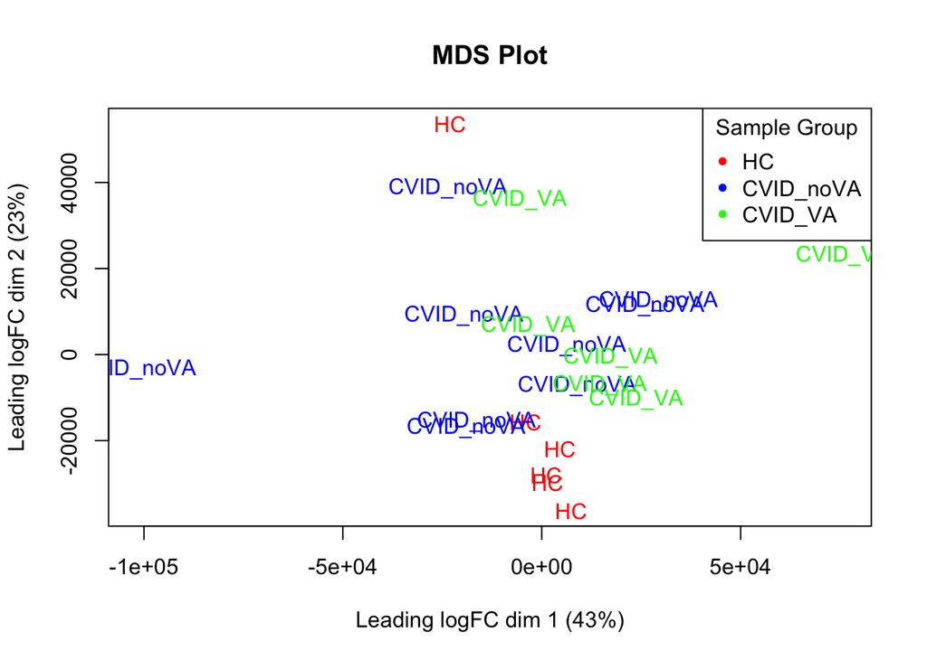

```r
library(limma)

# Define the sample groups
sample_groups <- c(rep("HC", 6), rep("CVID_noVA", 9), rep("CVID_VA", 6))

# Define the colors for each group
group_colors <- c("red", "blue", "green")
names(group_colors) <- unique(sample_groups)

# Create the MDS plot
mds <- plotMDS(final_data, labels = sample_groups, col = group_colors[sample_groups])
title("MDS Plot")

# Add a legend
legend("topright", legend = unique(sample_groups), pch = 20, col = group_colors, title = "Sample Group")
```

## Define model design

```r
# Create a factor for the sample groups
sample_groups_factor <- factor(sample_groups, levels = c("HC", "CVID_noVA", "CVID_VA"))

# Create the design matrix
design <- model.matrix(~ 0 + sample_groups_factor)

# Assign appropriate column names
colnames(design) <- c("HC", "CVID_noVA", "CVID_VA")
```

## Calculate p-values

In the differential expression analysis, I used an adjusted p-value threshold of < 0.05 to determine significantly differentially expressed genes.

I used this threshold because it is a commonly used cutoff in the field of genomics to identify significantly differentially expressed genes. An FDR threshold of 0.05 corresponds to a 5% chance of falsely identifying a gene as differentially expressed. This threshold provides a balance between sensitivity (i.e., identifying true positives) and specificity (i.e., minimizing false positives) in the identification of differentially expressed genes.

Number of genes passed correction (CVID_noVA vs HC):13

The adjusted p-value is obtained by controlling the false discovery rate (FDR) using the Benjamini-Hochberg (BH) method.

The BH method is a popular method for controlling the false discovery rate (FDR) when performing multiple hypothesis testing. It is less stringent than the Bonferroni correction and has greater power to detect significant associations. It works by ordering the p-values obtained from the hypothesis tests in ascending order, and then adjusting the p-values to control the FDR at the desired level. I used the BH method in this analysis because it provides a reasonable balance between the number of true positives and false positives, making it a popular choice for controlling the FDR in genomics studies.

## Generate Volcano plot

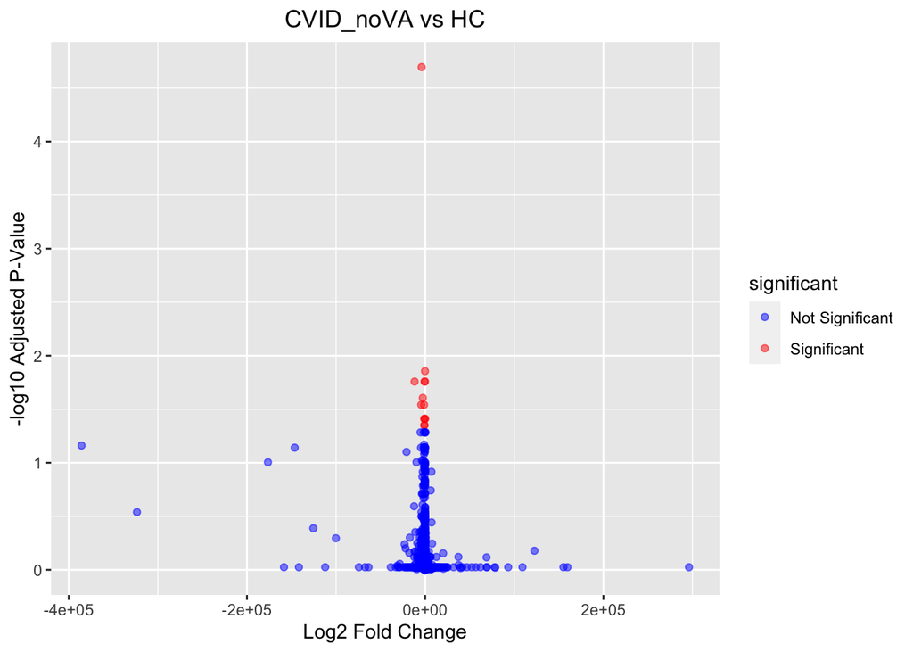

```r
library(ggplot2)

# Function to create a volcano plot
create_volcano_plot <- function(results, title) {
  # Define the data frame for the volcano plot
  volcano_data <- data.frame(
    logFC = results$logFC,
    neg_log10_adj_P = -log10(results$adj.P.Val),
    adj_P = results$adj.P.Val
  )

  # Set the threshold for significance
  threshold <- 0.05

  # Assign a significance status to each gene
  volcano_data$significant <- ifelse(volcano_data$adj_P < threshold, "Significant", "Not Significant")

  # Create the volcano plot
  volcano_plot <- ggplot(volcano_data, aes(x = logFC, y = neg_log10_adj_P, color = significant)) +
    geom_point(alpha = 0.5) +
    ggtitle(title) +
    theme(plot.title = element_text(hjust = 0.5)) +
    xlab("Log2 Fold Change") +
    ylab("-log10 Adjusted P-Value") +
    scale_color_manual(values = c("blue", "red"))

  return(volcano_plot)
}

# Create volcano plots for each contrast
volcano_CVID_noVA_vs_HC <- create_volcano_plot(results_CVID_noVA_vs_HC, "CVID_noVA vs HC")
volcano_CVID_VA_vs_HC <- create_volcano_plot(results_CVID_VA_vs_HC, "CVID_VA vs HC")
volcano_CVID_VA_vs_noVA <- create_volcano_plot(results_CVID_VA_vs_noVA, "CVID_VA vs noVA")

# Display the volcano plots
print(volcano_CVID_noVA_vs_HC)
```

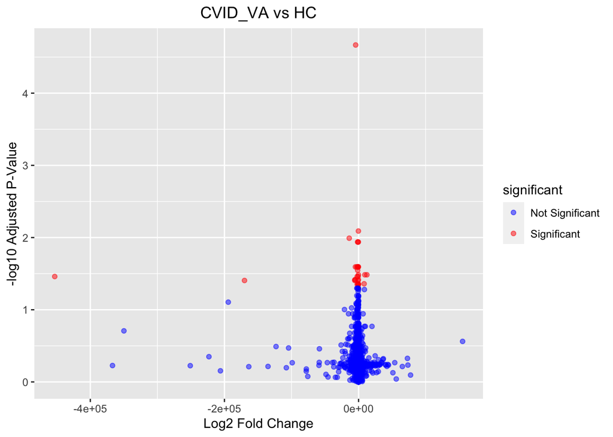

```r
print(volcano_CVID_VA_vs_HC)
```

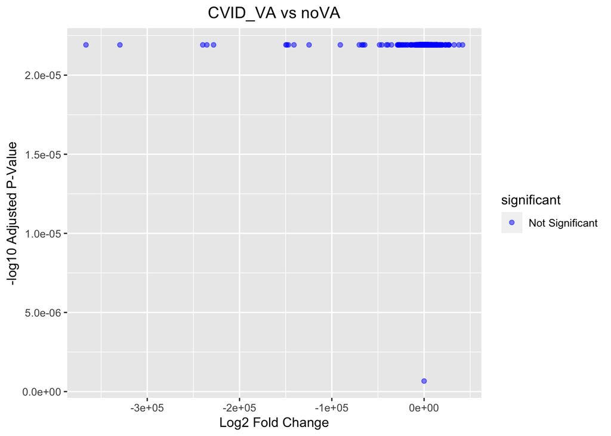

```r
print(volcano_CVID_VA_vs_noVA)
```

## Generate heatmap

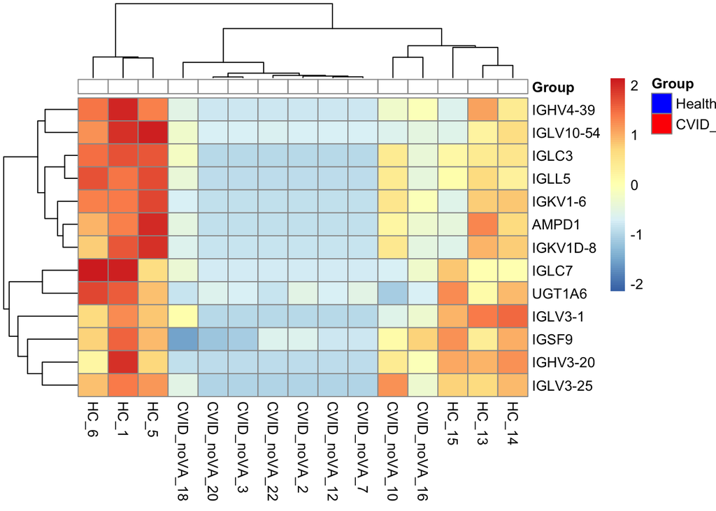

```r
# Set the threshold for adjusted p-values
threshold <- 0.05

# Select the differentially expressed genes for each contrast
DE_genes_CVID_noVA_vs_HC <- rownames(results_CVID_noVA_vs_HC[results_CVID_noVA_vs_HC$adj.P.Val < threshold, ])
DE_genes_CVID_VA_vs_HC <- rownames(results_CVID_VA_vs_HC[results_CVID_VA_vs_HC$adj.P.Val < threshold, ])
DE_genes_CVID_VA_vs_noVA <- rownames(results_CVID_VA_vs_noVA[results_CVID_VA_vs_noVA$adj.P.Val < threshold, ])

# Set the layout for the plots
par(mfrow = c(1, 2))

# Filter final_data to include only Healthy Control and CVID_noVA samples
final_data_filtered_noVA_vs_HC <- final_data[, sample_groups %in% c("HC", "CVID_noVA")]
final_data_filtered_VA_vs_HC <- final_data[, sample_groups %in% c("HC", "CVID_VA")]

# Generate a heatmap for each contrast
heatmap_CVID_noVA_vs_HC <- pheatmap(final_data_filtered_noVA_vs_HC[DE_genes_CVID_noVA_vs_HC, ],
                                    cluster_rows = TRUE,
                                    cluster_cols = TRUE,
                                    scale = "row",
                                    annotation_col = data.frame(Group = sample_groups[sample_groups %in% c("HC", "CVID_noVA")]),
                                    annotation_colors = list(Group = c("Healthy Control" = "blue", "CVID_noVA" = "red")),
                                    annotation_legend_param = list(title = "Group", labels = c("HC", "CVID_noVA"), fontsize = 12),
                                    show_rownames = TRUE,
                                    show_colnames = TRUE,
                                    silent = TRUE)

heatmap_CVID_VA_vs_HC <- pheatmap(final_data_filtered_VA_vs_HC[DE_genes_CVID_VA_vs_HC, ],
                                  cluster_rows = TRUE,
                                  cluster_cols = TRUE,
                                  scale = "row",
                                  annotation_col = data.frame(Group = sample_groups),
                                  annotation_colors = list(Group = c("Healthy Control" = "blue", "CVID_VA" = "red")),
                                  annotation_legend_param = list(title = "Group", labels = c("HC", "CVID_VA"), fontsize = 12),
                                  show_rownames = TRUE,
                                  show_colnames = TRUE,
                                  silent = TRUE)

# Display the heatmaps
grid::grid.newpage()
grid::grid.draw(heatmap_CVID_noVA_vs_HC$gtable)
```

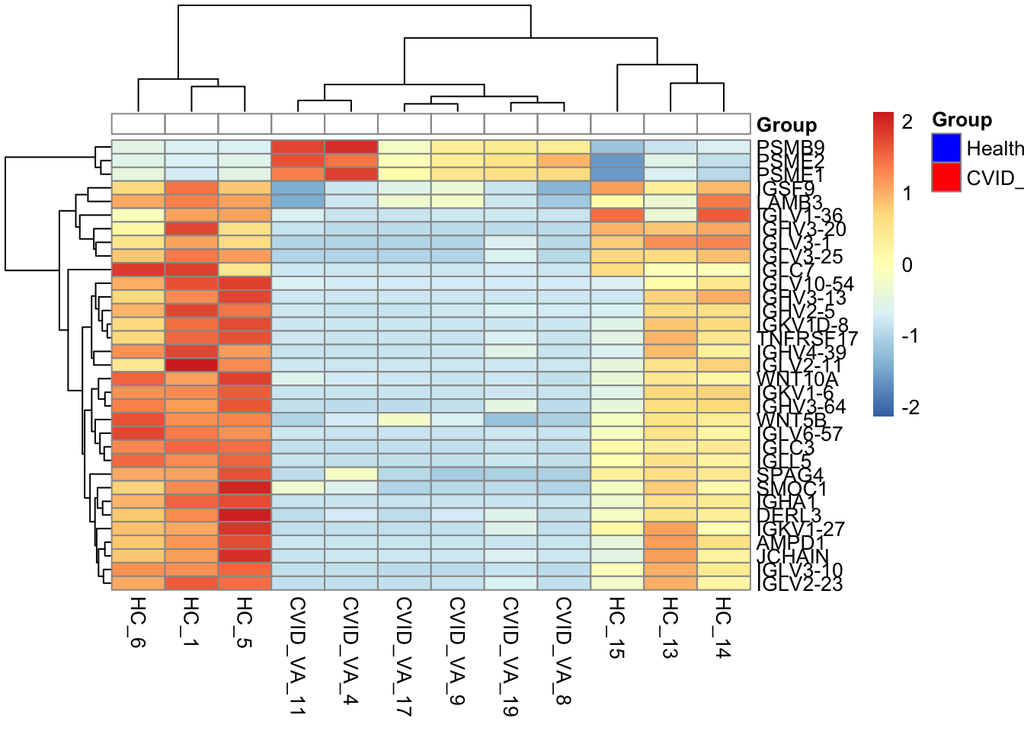

```r
grid::grid.newpage()
grid::grid.draw(heatmap_CVID_VA_vs_HC$gtable)
```

The heatmap_CVID_noVA_vs_HC represents the gene expression patterns of differentially expressed genes between the Healthy Control (HC) and CVID_noVA groups. In this heatmap, each row represents a differentially expressed gene, and each column represents a sample. The colors in the heatmap represent the relative expression level of the genes:

Orange or red: Higher expression level in the respective sample.

Light blue or yellow: Lower expression level in the respective sample.

In the heatmap_CVID_VA_vs_HC, each row represents a differentially expressed gene, and each column represents a sample. This heatmap compares the gene expression patterns between the Healthy Control (HC) and CVID_VA groups. The colors in the heatmap represent the relative expression level of the genes:

Orange or red: Higher expression level in the respective sample.

Light blue: Lower expression level in the respective sample.

Further analysis, such as functional enrichment analysis, could help reveal the biological pathways and processes associated with these differentially expressed genes.

# Thresholded over-representation analysis

```r
# CVID_noVA_vs_HC
# filter results_CVID_noVA_vs_HC for up-regulated genes
results_CVID_noVA_vs_HC_up <- subset(results_CVID_noVA_vs_HC, logFC >= 0 & adj.P.Val <= 0.1)
# convert HUGO symbols to Entrez IDs
entrez_ids <- mapIds(org.Hs.eg.db, keys=row.names(results_CVID_noVA_vs_HC_up), column="ENTREZID", keytype="SYMBOL", multiVals="first")
results_CVID_noVA_vs_HC_up$EntrezID <- entrez_ids
# run TORA on up-regulated genes
CVID_noVA_vs_HC_up <- enrichKEGG(gene = results_CVID_noVA_vs_HC_up$EntrezID, organism = 'hsa', pvalueCutoff = 0.05)
```

```
## Reading KEGG annotation online: "https://rest.kegg.jp/link/hsa/pathway"...
```

```
## Reading KEGG annotation online: "https://rest.kegg.jp/list/pathway/hsa"...
```

```r
# filter results_CVID_noVA_vs_HC for down-regulated genes
results_CVID_noVA_vs_HC_down <- subset(results_CVID_noVA_vs_HC, logFC <= 0 & adj.P.Val <= 0.1)
# convert HUGO symbols to Entrez IDs
entrez_ids <- mapIds(org.Hs.eg.db, keys=row.names(results_CVID_noVA_vs_HC_down), column="ENTREZID", keytype="SYMBOL", multiVals="first")
results_CVID_noVA_vs_HC_down$EntrezID <- entrez_ids
# run TORA on down-regulated genes
CVID_noVA_vs_HC_down <- enrichKEGG(gene = results_CVID_noVA_vs_HC_down$EntrezID, organism = 'hsa', pvalueCutoff = 0.05)

as.data.frame(CVID_noVA_vs_HC_up)
```

|  | ID | Description | GeneRatio | BgRatio | pvalue | p.adjust | qvalue | geneID | Count |
| --- | --- | --- | --- | --- | --- | --- | --- | --- | --- |
| hsa04360 | hsa04360 | Axon guidance | 1/1 | 182/8378 | 0.02172356 | 0.02172356 | NA | 64221 | 1 |

```r
as.data.frame(CVID_noVA_vs_HC_down)
```

|  | ID | Description | GeneRatio | BgRatio | pvalue | p.adjust | qvalue | geneID | Count |
| --- | --- | --- | --- | --- | --- | --- | --- | --- | --- |
| hsa00053 | hsa00053 | Ascorbate and aldarate metabolism | 2/13 | 30/8378 | 0.0009434888 | 0.02523541 | 0.01593815 | 54578/9104 | 2 |
| hsa00040 | hsa00040 | Pentose and glucuronate interconversions | 2/13 | 35/8378 | 0.0012848832 | 0.02523541 | 0.01593815 | 54578/57016 | 2 |
| hsa05340 | hsa05340 | Primary immunodeficiency | 2/13 | 38/8378 | 0.0015141246 | 0.02523541 | 0.01593815 | 23495/973 | 2 |
| hsa04672 | hsa04672 | Intestinal immune network for IgA production | 2/13 | 49/8378 | 0.0025086082 | 0.03135760 | 0.01980480 | 608/23495 | 2 |
| hsa05217 | hsa05217 | Basal cell carcinoma | 2/13 | 63/8378 | 0.0041153640 | 0.04115364 | 0.02599177 | 80326/81029 | 2 |

```r
# Run the analysis with all differentially expressed genes together
# filter results_CVID_noVA_vs_HC for differentially expressed genes
results_CVID_noVA_vs_HC_DE <- subset(results_CVID_noVA_vs_HC, adj.P.Val <= 0.1)
# convert HUGO symbols to Entrez IDs
entrez_ids <- mapIds(org.Hs.eg.db, keys=row.names(results_CVID_noVA_vs_HC_DE), column="ENTREZID", keytype="SYMBOL", multiVals="first")
results_CVID_noVA_vs_HC_DE$EntrezID <- entrez_ids
# run TORA on differentially expressed genes
CVID_noVA_vs_HC_all <- enrichKEGG(gene = results_CVID_noVA_vs_HC_DE$EntrezID, organism = 'hsa', pvalueCutoff = 0.05)

as.data.frame(CVID_noVA_vs_HC_all)
```

|  | ID | Description | GeneRatio | BgRatio | pvalue | p.adjust | qvalue | geneID | Count |
| --- | --- | --- | --- | --- | --- | --- | --- | --- | --- |
| hsa00053 | hsa00053 | Ascorbate and aldarate metabolism | 2/14 | 30/8378 | 0.001098289 | 0.02935721 | 0.01854139 | 54578/9104 | 2 |
| hsa00040 | hsa00040 | Pentose and glucuronate interconversions | 2/14 | 35/8378 | 0.001495104 | 0.02935721 | 0.01854139 | 54578/57016 | 2 |
| hsa05340 | hsa05340 | Primary immunodeficiency | 2/14 | 38/8378 | 0.001761432 | 0.02935721 | 0.01854139 | 23495/973 | 2 |
| hsa04672 | hsa04672 | Intestinal immune network for IgA production | 2/14 | 49/8378 | 0.002915807 | 0.03644759 | 0.02301953 | 608/23495 | 2 |
| hsa05217 | hsa05217 | Basal cell carcinoma | 2/14 | 63/8378 | 0.004778082 | 0.04778082 | 0.03017736 | 80326/81029 | 2 |

```r
# CVID_VA_vs_HC
# filter results_CVID_VA_vs_HC for up-regulated genes
results_CVID_VA_vs_HC_up <- subset(results_CVID_VA_vs_HC, logFC >= 0 & adj.P.Val <= 0.1)
# convert HUGO symbols to Entrez IDs
entrez_ids <- mapIds(org.Hs.eg.db, keys=row.names(results_CVID_VA_vs_HC_up), column="ENTREZID", keytype="SYMBOL", multiVals="first")
results_CVID_VA_vs_HC_up$EntrezID <- entrez_ids
# run TORA on up-regulated genes
CVID_VA_vs_HC_up <- enrichKEGG(gene = results_CVID_VA_vs_HC_up$EntrezID, organism = 'hsa', pvalueCutoff = 0.05)

# filter results_CVID_noVA_vs_HC for down-regulated genes
results_CVID_VA_vs_HC_down <- subset(results_CVID_VA_vs_HC, logFC <= 0 & adj.P.Val <= 0.1)
# convert HUGO symbols to Entrez IDs
entrez_ids <- mapIds(org.Hs.eg.db, keys=row.names(results_CVID_VA_vs_HC_down), column="ENTREZID", keytype="SYMBOL", multiVals="first")
results_CVID_VA_vs_HC_down$EntrezID <- entrez_ids
# run TORA on down-regulated genes
CVID_VA_vs_HC_down <- enrichKEGG(gene = results_CVID_VA_vs_HC_down$EntrezID, organism = 'hsa', pvalueCutoff = 0.05)

as.data.frame(CVID_VA_vs_HC_up)
```

|  | ID | Description | GeneRatio | BgRatio | pvalue | p.adjust | qvalue | geneID | Count |
| --- | --- | --- | --- | --- | --- | --- | --- | --- | --- |
| hsa03050 | hsa03050 | Proteasome | 3/4 | 46/8378 | 6.173648e-07 | 1.111257e-05 | 7.148435e-06 | 5721/5720/5698 | 3 |
| hsa04612 | hsa04612 | Antigen processing and presentation | 3/4 | 78/8378 | 3.085081e-06 | 2.776573e-05 | 1.786100e-05 | 5721/5720/3134 | 3 |

```r
as.data.frame(CVID_VA_vs_HC_down)
```

|  | ID | Description | GeneRatio | BgRatio | pvalue | p.adjust | qvalue | geneID | Count |
| --- | --- | --- | --- | --- | --- | --- | --- | --- | --- |
| hsa04672 | hsa04672 | Intestinal immune network for IgA production | 3/17 | 49/8378 | 0.0001207008 | 0.006759244 | 0.004319817 | 608/23495/2826 | 3 |
| hsa05204 | hsa05204 | Chemical carcinogenesis - DNA adducts | 3/17 | 69/8378 | 0.0003347378 | 0.008970788 | 0.005733210 | 54578/2052/2947 | 3 |
| hsa00980 | hsa00980 | Metabolism of xenobiotics by cytochrome P450 | 3/17 | 78/8378 | 0.0004805779 | 0.008970788 | 0.005733210 | 54578/2052/2947 | 3 |
| hsa00040 | hsa00040 | Pentose and glucuronate interconversions | 2/17 | 35/8378 | 0.0022169351 | 0.024359868 | 0.015568337 | 54578/57016 | 2 |
| hsa04060 | hsa04060 | Cytokine-cytokine receptor interaction | 4/17 | 295/8378 | 0.0024926070 | 0.024359868 | 0.015568337 | 608/654/23495/2826 | 4 |
| hsa05340 | hsa05340 | Primary immunodeficiency | 2/17 | 38/8378 | 0.0026099859 | 0.024359868 | 0.015568337 | 23495/973 | 2 |
| hsa04390 | hsa04390 | Hippo signaling pathway | 3/17 | 157/8378 | 0.0036193824 | 0.028955059 | 0.018505113 | 81029/80326/654 | 3 |
| hsa05225 | hsa05225 | Hepatocellular carcinoma | 3/17 | 168/8378 | 0.0043793680 | 0.030655576 | 0.019591909 | 81029/80326/2947 | 3 |
| hsa05217 | hsa05217 | Basal cell carcinoma | 2/17 | 63/8378 | 0.0070380676 | 0.043792421 | 0.027987637 | 81029/80326 | 2 |
| hsa05207 | hsa05207 | Chemical carcinogenesis - receptor activation | 3/17 | 212/8378 | 0.0083581313 | 0.046393498 | 0.029649980 | 54578/2052/2947 | 3 |

[output cut: 1 more lines]

```r
# Run the analysis with all differentially expressed genes together
# filter results_CVID_VA_vs_HC for differentially expressed genes
results_CVID_VA_vs_HC_DE <- subset(results_CVID_VA_vs_HC, adj.P.Val <= 0.1)
# convert HUGO symbols to Entrez IDs
entrez_ids <- mapIds(org.Hs.eg.db, keys=row.names(results_CVID_VA_vs_HC_DE), column="ENTREZID", keytype="SYMBOL", multiVals="first")
results_CVID_VA_vs_HC_DE$EntrezID <- entrez_ids
# run TORA on differentially expressed genes
CVID_VA_vs_HC_all <- enrichKEGG(gene = results_CVID_VA_vs_HC_DE$EntrezID, organism = 'hsa', pvalueCutoff = 0.05)

as.data.frame(CVID_VA_vs_HC_all)
```

|  | ID | Description | GeneRatio | BgRatio | pvalue | p.adjust | qvalue | geneID | Count |
| --- | --- | --- | --- | --- | --- | --- | --- | --- | --- |
| hsa03050 | hsa03050 | Proteasome | 3/21 | 46/8378 | 0.0001922608 | 0.008476082 | 0.006722199 | 5721/5720/5698 | 3 |
| hsa04672 | hsa04672 | Intestinal immune network for IgA production | 3/21 | 49/8378 | 0.0002322214 | 0.008476082 | 0.006722199 | 608/23495/2826 | 3 |
| hsa05204 | hsa05204 | Chemical carcinogenesis - DNA adducts | 3/21 | 69/8378 | 0.0006394380 | 0.013360365 | 0.010595819 | 54578/2052/2947 | 3 |
| hsa00980 | hsa00980 | Metabolism of xenobiotics by cytochrome P450 | 3/21 | 78/8378 | 0.0009150935 | 0.013360365 | 0.010595819 | 54578/2052/2947 | 3 |
| hsa04612 | hsa04612 | Antigen processing and presentation | 3/21 | 78/8378 | 0.0009150935 | 0.013360365 | 0.010595819 | 5721/5720/3134 | 3 |
| hsa00040 | hsa00040 | Pentose and glucuronate interconversions | 2/21 | 35/8378 | 0.0033875276 | 0.041214919 | 0.032686670 | 54578/57016 | 2 |
| hsa05340 | hsa05340 | Primary immunodeficiency | 2/21 | 38/8378 | 0.0039843387 | 0.041550961 | 0.032953177 | 23495/973 | 2 |

I chose to use the enrichKEGG function from the clusterProfiler package for Thresholded Over-Representation Analysis (TORA). I chose this method because it allows me to easily perform pathway analysis on a list of genes and obtain enrichment results for KEGG pathways. Additionally, the enrichKEGG function has parameters to set the p-value cutoff and the organism to perform the analysis on. enrichKEGG uses a hypergeometric test with Benjamini and Hochberg multiple testing correction to identify KEGG pathways that are overrepresented in a user-defined set of genes. This algorithm compares the set of genes of interest with the entire genome background to find if any pathways are significantly overrepresented in the set of genes of interest compared to the background. The p-value of each enriched pathway is adjusted for multiple testing using the Benjamini and Hochberg method to control the false discovery rate.

The annotation data used is from the org.Hs.eg.db package (version 3.15.0), which provides an interface to the Human Genome Organization (HUGO) database. This package maps different types of gene IDs to HUGO symbols, which are standardized gene symbols widely used in the scientific community. I chose this annotation data because HUGO symbols are widely used and can facilitate comparison of results across studies.

The fold change threshold and the adjusted p-value threshold are commonly used to filter differentially expressed genes in gene expression analysis. The fold change threshold determines the magnitude of change in gene expression between two groups, while the adjusted p-value threshold determines the level of statistical significance of the differential expression.

In this case, a fold change threshold of 0 is chosen because we want to identify both up- and down-regulated genes in the analysis. If we set the fold change threshold to a positive value, we would only identify up-regulated genes, and if we set it to a negative value, we would only identify down-regulated genes.

The adjusted p-value threshold of 0.1 is chosen to allow for a slightly higher false discovery rate (FDR) than the commonly used threshold of 0.05. This is because we want to identify as many potentially significant biological pathways as possible, and a more relaxed threshold can help to achieve this. However, it is important to note that a higher FDR threshold increases the risk of false positive results, so the results should be interpreted with caution and validated with further experimental evidence.

The reason for the difference in the number of genes identified by TORA when analyzing the up-regulated and down-regulated genes separately versus analyzing all differentially expressed genes together is due to the way TORA works.

By running the analysis with all differentially expressed genes together, we are including all genes that are significantly differentially expressed, regardless of direction. This can provide a more comprehensive view of the biological pathways that are affected in the condition being studied.

However, it is important to note that the results may be more difficult to interpret when all genes are included, as the biological pathways enriched may not be specific to the up-regulated or down-regulated genes. It may be useful to perform both analyses (separately and together) to gain a more complete understanding of the biological pathways affected in the condition being studied.

# Interpretation

Based on the TORA results provided, there is some evidence to support the conclusions and mechanisms discussed in the original paper.

The TORA results for the comparison of CVID_VA_vs_HC_up showed an over-representation of the Proteasome pathway (hsa03050) and Antigen processing and presentation pathway (hsa04612), with a significant gene ratio and low p-values. These pathways are known to be involved in immune regulation and are consistent with the study’s findings of T-cell cytotoxicity and immune dysregulation in CVID enteropathy.

Additionally, the TORA results for the comparison of CVID_VA_vs_HC_down showed an over-representation of pathways related to immune response, including Intestinal immune network for IgA production (hsa04672) and Primary immunodeficiency (hsa05340). These pathways are consistent with the study’s findings of decreased intestinal IgA-producing cells and immune dysregulation in CVID enteropathy.

Overall, while further studies are needed to confirm these findings, the TORA results and existing literature support the conclusions and mechanisms discussed in the original paper.

# Reference

Alexa, A., and Rahnenfuhrer, J. 2021. topGO: Enrichment Analysis for Gene Ontology. R package version 2.46.0.

Benjamini Y, Hochberg Y. Controlling the False Discovery Rate: A Practical and Powerful Approach to Multiple Testing. Journal of the Royal Statistical Society: Series B (Methodological). 1995;57(1):289-300. doi: 10.1111/j.2517-6161.1995.tb02031.x.

Carlson M. org.Hs.eg.db: Genome wide annotation for Human [Internet]. R package version 3.15.0. 2021. Available from: https://bioconductor.org/packages/release/data/annotation/html/org.Hs.eg.db.html

Davis S, Meltzer PS. GEOmetadb: Genome Omnibus metadata database [Internet]. R package version 1.52.0. 2021. Available from: https://bioconductor.org/packages/release/data/annotation/html/GEOmetadb.html

Durinck S, Spellman PT, Birney E, Huber W. biomaRt: Interface to BioMart databases [Internet]. R package version 2.52.0. 2021. Available from: https://bioconductor.org/packages/release/bioc/html/biomaRt.html

Kelsen, J. R., Sullivan, K. E., Rabizadeh, S., Singh, N., Snapper, S., Elkadri, A., … & Rufo, P. A. (2018). North American Society for Pediatric Gastroenterology, Hepatology, and Nutrition position paper on the diagnosis and management of hepatitis C virus infection in infants, children, and adolescents. Journal of pediatric gastroenterology and nutrition, 67(1), 123-135.

Perng W, Gillen DL. Thresholds in Epidemiology. In: Rothman KJ, Greenland S, Lash TL, eds. Modern Epidemiology. 3rd ed. Lippincott Williams & Wilkins; 2008:508-523.

Robinson MD, McCarthy DJ, Smyth GK. edgeR: a Bioconductor package for differential expression analysis of digital gene expression data [Internet]. R package version 3.36.0. 2021. Available from: https://bioconductor.org/packages/release/bioc/html/edgeR.html

Strohmeier V, Andrieux G, Unger S, Pascual-Reguant A, Klocperk A, Seidl M, et al. Interferon-driven immune dysregulation in common variable immunodeficiency-associated villous atrophy and norovirus infection. J Clin Immunol. 2022;42(2):365-383. doi: 10.1007/s10875-022-01379-2.

Subramanian A, Tamayo P, Mootha VK, Mukherjee S, Ebert BL, Gillette MA, Paulovich A, Pomeroy SL, Golub TR, Lander ES, Mesirov JP. 2005. Gene set enrichment analysis: a knowledge-based approach for interpreting genome-wide expression profiles. Proc Natl Acad Sci U S A. 102(43):15545-15550.

Vossenkämper, A., Komban, R. J., Huang, X., Yang, H., Deng, S., Ammann, S., … & Liu, C. (2019). Microbial-induced meprin β cleavage in MUC2 mucin and a functional CFTR channel are required to counteract pro-inflammatory responses in intestinal epithelial cells. Frontiers in immunology, 10, 2481.

Wickham H. ggplot2: Elegant Graphics for Data Analysis [Internet]. R package version 3.3.5. 2021. Available from: https://CRAN.R-project.org/package=ggplot2

Wickham H. reshape2: Flexibly Reshape Data: A Reboot of the Reshape Package [Internet]. R package version 1.4.4. 2021. Available from: https://CRAN.R-project.org/package=reshape2

Xie Y. knitr: A General-Purpose Package for Dynamic Report Generation in R [Internet]. R package version 1.36. 2021. Available from: https://CRAN.R-project.org/package=knitr